# Lab 8

```python
import pandas as pd
from sklearn.model_selection import GridSearchCV
from sklearn.pipeline import Pipeline
from sklearn.preprocessing import StandardScaler
from sklearn.discriminant_analysis import LinearDiscriminantAnalysis
from sklearn.metrics import confusion_matrix, f1_score
import numpy as np
from sklearn.model_selection import cross_val_score
from sklearn.discriminant_analysis import QuadraticDiscriminantAnalysis
from sklearn.svm import SVC
from sklearn.linear_model import LogisticRegression
```

```python
df = pd.read_csv("https://www.dropbox.com/s/s2a1uoiegitupjc/cannabis_full.csv?dl=1")
df.dropna(inplace=True)
```

# Part 1

```python
df_p1 = df[df["Type"].isin(["sativa", "indica"])].copy()

X = df_p1.drop(columns=['Type', 'Strain', 'Effects', 'Flavor'])
y = df_p1['Type']

df_p1['Type'].value_counts()
```

```
Type
indica    659
sativa    409
Name: count, dtype: int64
```

I am choosing f1_macro as my metric due to the fact that it disregards the number of each type

## Q1 LDA

```python
lda_model = Pipeline(
  [("standardize", StandardScaler()),
  ("lda", LinearDiscriminantAnalysis())]
)

params_lda = {
    "lda__solver": ['lsqr'],
    "lda__shrinkage": ['auto', None, 0.2, 0.4, 0.6, 0.8, 1]
}

grid_search = GridSearchCV(lda_model, params_lda, cv=5, scoring='f1_macro')
grid_search.fit(X, y)

best_model_lda = grid_search.best_estimator_
y_pred_lda = best_model_lda.predict(X)
f1_score_lda = f1_score(y, y_pred_lda, average='macro')

lda_scores = cross_val_score(best_model_lda, X, y, cv = 5, scoring = 'f1_macro')

f1_cv_lda = np.mean(lda_scores)
print(f"Cross Validated f1_macro score (LDA): {f1_cv_lda}")

best_model_lda.fit(X, y)
confusion_matrix(y, y_pred_lda)
```

```
Cross Validated f1_macro score (LDA): 0.8585525348155478
```

```
array([[601,  58],
       [ 69, 340]])
```

## Q2 QDA

```python
qda_model = Pipeline(
  [("standardize", StandardScaler()),
  ("qda", QuadraticDiscriminantAnalysis())]
)

params_qda = {
    'qda__reg_param': [0.01, 0.1, 0.3, 0.5, 0.7, 0.9],
    'qda__store_covariance': [False, True]
}

grid_search = GridSearchCV(qda_model, params_qda, cv=5, scoring='f1_macro')
grid_search.fit(X, y)

best_model_qda = grid_search.best_estimator_
y_pred_qda = best_model_qda.predict(X)
f1_score_qda = f1_score(y, y_pred_qda, average='macro')

qda_scores = cross_val_score(best_model_qda, X, y, cv = 5, scoring = 'f1_macro')

f1_cv_qda = np.mean(qda_scores)
print(f"Cross Validated f1_macro score (QDA): {f1_cv_qda}")

best_model_qda.fit(X, y)
confusion_matrix(y, y_pred_qda)
```

```
Cross Validated f1_macro score (QDA): 0.8212536958125318
```

```
array([[589,  70],
       [ 56, 353]])
```

## Q3 SVC

```python
svc_model = Pipeline(
  [("standardize", StandardScaler()),
  ("svc", SVC(kernel="linear"))]
)

params_svc = {
    "svc__C": [0.1, 1, 10, 100],
    "svc__gamma": ['scale', 'auto']
}

grid_search = GridSearchCV(svc_model, params_svc, cv=5, scoring='f1_macro')
grid_search.fit(X, y)

best_model_svc = grid_search.best_estimator_
y_pred_svc = best_model_svc.predict(X)
f1_score_svc = f1_score(y, y_pred_svc, average='macro')

svc_scores = cross_val_score(best_model_svc, X, y, cv = 5, scoring = 'f1_macro')

f1_cv_svc = np.mean(svc_scores)
print(f"Cross Validated f1_macro score (SVC): {f1_cv_svc}")

best_model_svc.fit(X, y)
confusion_matrix(y, y_pred_svc)
```

```
Cross Validated f1_macro score (SVC): 0.8492651917944508
```

```
array([[609,  50],
       [ 65, 344]])
```

## Q4 SVM

```python
svm_model = Pipeline(
  [("standardize", StandardScaler()),
  ("svc", SVC(kernel="poly"))]
)

params_svm = {
    "svc__C": [0.1, 1, 10, 100],
    "svc__degree": [2, 3, 5, 10],
    "svc__gamma": ['scale', 'auto']
}

grid_search = GridSearchCV(svm_model, params_svm, cv=5, scoring='f1_macro')
grid_search.fit(X, y)

best_model_svm = grid_search.best_estimator_
y_pred_svm = best_model_svm.predict(X)
f1_score_svm = f1_score(y, y_pred_svm, average='macro')

svm_scores = cross_val_score(best_model_svm, X, y, cv = 5, scoring = 'f1_macro')

f1_cv_svm = np.mean(svm_scores)
print(f"Cross Validated f1_macro score (SVM): {f1_cv_svm}")

best_model_svm.fit(X, y)
confusion_matrix(y, y_pred_svm)
```

```
Cross Validated f1_macro score (SVM): 0.8302668457147376
```

```
array([[657,   2],
       [ 24, 385]])
```

Based on the cross validated f1_macro scores, the LDA model was the best

# Part 2

```python
X = df.drop(columns=['Type', 'Strain', 'Effects', 'Flavor'])
y = df['Type']
```

## Q1 Tree

```python
from sklearn.tree import DecisionTreeClassifier

tree_pipeline = Pipeline(
  [("standardize", StandardScaler()),
  ("tree", DecisionTreeClassifier())]
)

tree_pipeline

tree_pipeline_fitted = tree_pipeline.fit(X, y)

y_preds_tree = tree_pipeline_fitted.predict(X)

param_grid_tree = {
    "tree__max_depth": [1, 3, 7, 9],
    'tree__min_samples_leaf': [1, 2, 4, 6, 8],
    'tree__criterion': ['gini', 'entropy', 'log_loss']
    }

grid_search = GridSearchCV(tree_pipeline, param_grid_tree, cv=5, scoring='f1_macro')
grid_search.fit(X, y)
# tree_df_cv_results_ = pd.DataFrame(tree_grid_search_fitted.cv_results_)

best_model_tree = grid_search.best_estimator_
y_pred_tree = best_model_tree.predict(X)
f1_score_tree = f1_score(y, y_pred_tree, average='macro')


tree_scores = cross_val_score(best_model_tree, X, y, cv = 5, scoring = 'f1_macro')

f1_cv_tree = np.mean(tree_scores)
print(f"Cross Validated f1_macro score (Tree): {f1_cv_tree}")

best_model_tree.fit(X, y)
confusion_matrix(y, y_pred_tree)
```

```
Cross Validated f1_macro score (Tree): 0.5911690855182161
```

```
array([[757, 232, 134],
       [193, 455,  11],
       [214,  22, 173]])
```

```
[Text(0.5, 0.875, 'x[13] <= 0.367\nentropy = 1.468\nsamples = 2191\nvalue = [1123, 659, 409]'),
```

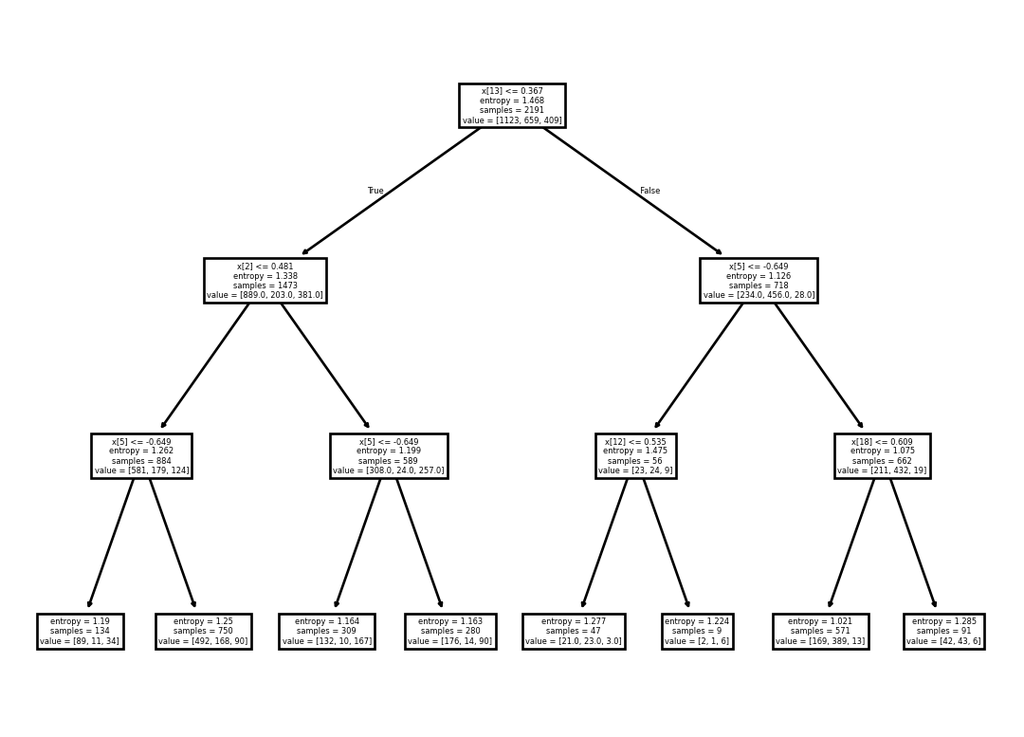

```python
best_tree = grid_search.best_estimator_.named_steps['tree']

from sklearn.tree import plot_tree

plot_tree(best_tree)
```

The decision tree has 3 splits based on a number of the perdictor variables. This gives us 4 layers of the tree with 8 leaf nodes. The most important predictor is at the top (column 13). This is the sleepy column. Column 5 is relaxed which is another significant predictor.

## Q2 LDA

```python
lda_model = Pipeline(
  [("standardize", StandardScaler()),
  ("lda", LinearDiscriminantAnalysis())]
)

params_lda = {
    "lda__solver": ['lsqr'],
    "lda__shrinkage": ['auto', None, 0.2, 0.4, 0.6, 0.8, 1]
}

grid_search = GridSearchCV(lda_model, params_lda, cv=5, scoring='f1_macro')
grid_search.fit(X, y)

best_model_lda = grid_search.best_estimator_
y_pred_lda = best_model_lda.predict(X)
f1_score_lda = f1_score(y, y_pred_lda, average='macro')

lda_scores = cross_val_score(best_model_lda, X, y, cv = 5, scoring = 'f1_macro')

f1_cv_lda = np.mean(lda_scores)
print(f"Cross Validated f1_macro score (LDA): {f1_cv_lda}")

best_model_lda.fit(X, y)
confusion_matrix(y, y_pred_lda)
```

```
Cross Validated f1_macro score (LDA): 0.6013687733740843
```

```
array([[727, 213, 183],
       [175, 463,  21],
       [180,  16, 213]])
```

## Q2 QDA

```python
qda_model = Pipeline(
  [("standardize", StandardScaler()),
  ("qda", QuadraticDiscriminantAnalysis())]
)

params_qda = {
    'qda__reg_param': [0.01, 0.1, 0.3, 0.5, 0.7, 0.9],
    'qda__store_covariance': [False, True]
}

grid_search = GridSearchCV(qda_model, params_qda, cv=5, scoring='f1_macro')
grid_search.fit(X, y)

best_model_qda = grid_search.best_estimator_
y_pred_qda = best_model_qda.predict(X)
f1_score_qda = f1_score(y, y_pred_qda, average='macro')

qda_scores = cross_val_score(best_model_qda, X, y, cv = 5, scoring = 'f1_macro')

f1_cv_qda = np.mean(qda_scores)
print(f"Cross Validated f1_macro score (QDA): {f1_cv_qda}")

best_model_qda.fit(X, y)
confusion_matrix(y, y_pred_qda)
```

```
Cross Validated f1_macro score (QDA): 0.560283964044076
```

```
array([[691, 222, 210],
       [149, 474,  36],
       [131,  18, 260]])
```

## Q2 KNN

```python
from sklearn.neighbors import KNeighborsClassifier

knn_pipeline = Pipeline(
  [("standardize", StandardScaler()),
  ("knn", KNeighborsClassifier())]
)

knn_pipeline_fitted = knn_pipeline.fit(X, y)

y_preds_knn = knn_pipeline_fitted.predict(X)

param_grid_knn = {
    'knn__n_neighbors': [3, 5, 7, 9, 11],
    'knn__weights': ['uniform', 'distance'],
    'knn__metric': ['euclidean', 'manhattan']
}

grid_search = GridSearchCV(knn_pipeline, param_grid_knn, cv=5, scoring='f1_macro')
grid_search.fit(X, y)

best_model_knn = grid_search.best_estimator_
y_pred_knn = best_model_knn.predict(X)
f1_score_knn = f1_score(y, y_pred_knn, average='macro')

knn_scores = cross_val_score(best_model_knn, X, y, cv = 5, scoring = 'f1_macro')

f1_cv_knn = np.mean(knn_scores)
print(f"Cross Validated f1_macro score (KNN): {f1_cv_knn}")

best_model_knn.fit(X, y)
confusion_matrix(y, y_pred_knn)
```

```
Cross Validated f1_macro score (KNN): 0.520608299011038
```

```
array([[1120,    2,    1],
       [  12,  647,    0],
       [   7,    2,  400]])
```

```python
from sklearn.model_selection import cross_val_predict

y_pred_cv_knn = cross_val_predict(best_model_knn, X, y, cv=5)
confusion_matrix(y, y_pred_cv_knn)
```

```
array([[782, 228, 113],
       [280, 370,   9],
       [269,  26, 114]])
```

I decided to plot the confusion matric on a cross valuated version of the predictions too. Due to the nature of knn, when cross valudating on f1 score the model was predicting with an abnormally high accuracy with a normal f1 score.

## Q3

My results were better in Part 1. This is becasue the introduction of the hybrids. Hybrids are hard to classify correctly because they have characterists of both indica and sativa. The hybrids were the ones that were most frequently predicted incorrect, this again, is because hybrids have characterists of both making it hard for the model to correctly predict.

# Part 3

## Q1

```python
y_indica = (y == 'indica').astype(int)
y_hybrid = (y == 'hybrid').astype(int)
y_sativa = (y == 'sativa').astype(int)
```

```python
indica_lr_model = Pipeline(
    [("scale", StandardScaler()),
    ("logistic_regression", LogisticRegression())]
)

param_grid_log = {
    'logistic_regression__C': [0.01, 0.1, 1, 10, 100]
}

grid_search = GridSearchCV(indica_lr_model, param_grid_log, cv=5, scoring='f1_macro')
grid_search.fit(X, y_indica)

best_model_lr_indica = grid_search.best_estimator_
y_pred_lr_indica = best_model_lr_indica.predict(X)
f1_score_lr_indica = f1_score(y_indica, y_pred_lr_indica, average='macro')

indica_lr_scores = cross_val_score(best_model_lr_indica, X, y_indica, cv = 5, scoring = 'f1_macro')

f1_cv_lr_indica = np.mean(indica_lr_scores)
print(f"Cross Validated f1_macro score (Indica lr): {f1_cv_lr_indica}")

best_model_lr_indica.fit(X, y_indica)
confusion_matrix(y_indica, y_pred_lr_indica)
```

```
Cross Validated f1_macro score (Indica lr): 0.7459200923067892
```

```
array([[1353,  179],
       [ 234,  425]])
```

```python
hybrid_lr_model = Pipeline(
    [("scale", StandardScaler()),
    ("logistic_regression", LogisticRegression())]
)

param_grid_log = {
    'logistic_regression__C': [0.01, 0.1, 1, 10, 100]
}

grid_search = GridSearchCV(hybrid_lr_model, param_grid_log, cv=5, scoring='f1_macro')
grid_search.fit(X, y_hybrid)

best_model_lr_hybrid = grid_search.best_estimator_
y_pred_lr_hybrid = best_model_lr_hybrid.predict(X)
f1_score_lr_hybrid = f1_score(y_hybrid, y_pred_lr_hybrid, average='macro')

hybrid_lr_scores = cross_val_score(best_model_lr_hybrid, X, y_hybrid, cv = 5, scoring = 'f1_macro')

f1_cv_lr_hybrid = np.mean(hybrid_lr_scores)
print(f"Cross Validated f1_macro score (hybrid lr): {f1_cv_lr_hybrid}")

best_model_lr_hybrid.fit(X, y_hybrid)
confusion_matrix(y_hybrid, y_pred_lr_hybrid)
```

```
Cross Validated f1_macro score (hybrid lr): 0.6140918697626863
```

```
array([[646, 422],
       [337, 786]])
```

```python
sativa_lr_model = Pipeline(
    [("scale", StandardScaler()),
    ("logistic_regression", LogisticRegression())]
)

param_grid_log = {
    'logistic_regression__C': [0.01, 0.1, 1, 10, 100]
}

grid_search = GridSearchCV(sativa_lr_model, param_grid_log, cv=5, scoring='f1_macro')
grid_search.fit(X, y_sativa)

best_model_lr_sativa = grid_search.best_estimator_
y_pred_lr_sativa = best_model_lr_sativa.predict(X)
f1_score_lr_sativa = f1_score(y_sativa, y_pred_lr_sativa, average='macro')

sativa_lr_scores = cross_val_score(best_model_lr_sativa, X, y_sativa, cv = 5, scoring = 'f1_macro')

f1_cv_lr_sativa = np.mean(sativa_lr_scores)
print(f"Cross Validated f1_macro score (sativa lr): {f1_cv_lr_sativa}")

best_model_lr_sativa.fit(X, y_sativa)
confusion_matrix(y_sativa, y_pred_lr_sativa)
```

```
Cross Validated f1_macro score (sativa lr): 0.649675523740159
```

```
array([[1689,   93],
       [ 263,  146]])
```

```python
indica_svc_model = Pipeline(
  [("standardize", StandardScaler()),
  ("svc", SVC())]
)

params_svc = {
    "svc__C": [0.1, 1, 10, 100],
    "svc__degree": [2, 3, 5, 10],
    "svc__gamma": ['scale', 'auto']
}

grid_search = GridSearchCV(indica_svc_model, params_svc, cv=5, scoring='f1_macro')
grid_search.fit(X, y_indica)

best_model_svc_indica = grid_search.best_estimator_
y_pred_svc_indica = best_model_svc_indica.predict(X)
f1_score_svc_indica = f1_score(y_indica, y_pred_svc_indica, average='macro')

indica_svc_scores = cross_val_score(best_model_svc_indica, X, y_indica, cv = 5, scoring = 'f1_macro')

f1_cv_svc_indica = np.mean(indica_svc_scores)
print(f"Cross Validated f1_macro score (indica svc): {f1_cv_svc_indica}")

best_model_svc_indica.fit(X, y_indica)
confusion_matrix(y_indica, y_pred_svc_indica)
```

```
Cross Validated f1_macro score (indica svc): 0.7204357790207705
```

```
array([[1383,  149],
       [ 196,  463]])
```

```python
hybrid_svc_model = Pipeline(
  [("standardize", StandardScaler()),
  ("svc", SVC())]
)

params_svc = {
    "svc__C": [0.1, 1, 10, 100],
    "svc__degree": [2, 3, 5, 10],
    "svc__gamma": ['scale', 'auto']
}

grid_search = GridSearchCV(hybrid_svc_model, params_svc, cv=5, scoring='f1_macro')
grid_search.fit(X, y_hybrid)

best_model_svc_hybrid = grid_search.best_estimator_
y_pred_svc_hybrid = best_model_svc_hybrid.predict(X)
f1_score_svc_hybrid = f1_score(y_hybrid, y_pred_svc_hybrid, average='macro')

hybrid_svc_scores = cross_val_score(best_model_svc_hybrid, X, y_hybrid, cv = 5, scoring = 'f1_macro')

f1_cv_svc_hybrid = np.mean(hybrid_svc_scores)
print(f"Cross Validated f1_macro score (hybrid svc): {f1_cv_svc_hybrid}")

best_model_svc_hybrid.fit(X, y_hybrid)
confusion_matrix(y_hybrid, y_pred_svc_hybrid)
```

```
Cross Validated f1_macro score (hybrid svc): 0.6129061743438917
```

```
array([[745, 323],
       [244, 879]])
```

```python
sativa_svc_model = Pipeline(
  [("standardize", StandardScaler()),
  ("svc", SVC())]
)

params_svc = {
    "svc__C": [0.1, 1, 10, 100],
    "svc__degree": [2, 3, 5, 10],
    "svc__gamma": ['scale', 'auto']
}

grid_search = GridSearchCV(sativa_svc_model, params_svc, cv=5, scoring='f1_macro')
grid_search.fit(X, y_sativa)

best_model_svc_sativa = grid_search.best_estimator_
y_pred_svc_sativa = best_model_svc_sativa.predict(X)
f1_score_svc_sativa = f1_score(y_sativa, y_pred_svc_sativa, average='macro')

sativa_svc_scores = cross_val_score(best_model_svc_sativa, X, y_sativa, cv = 5, scoring = 'f1_macro')

f1_cv_svc_sativa = np.mean(sativa_svc_scores)
print(f"Cross Validated f1_macro score (sativa svc): {f1_cv_svc_sativa}")

best_model_svc_sativa.fit(X, y_sativa)
confusion_matrix(y_sativa, y_pred_svc_sativa)
```

```
Cross Validated f1_macro score (sativa svc): 0.6390558086157123
```

```
array([[1751,   31],
       [  78,  331]])
```

## Q2

My Indica Logistic Model was the best with a cross validated F1_macro score of 0.75. My Hybrid SVC Model was the worst with a cross validated F1_macro score of 0.61.

My two worst models were the hybrid ones, this intuitvly makes sense as I would expect a hybrid to have characteristics of both indica and sativa, making it harder to distinguish between the three.

## Q3

```python
df_ind_vs_sat = df[(df["Type"] == "indica") | (df["Type"] == "sativa")]
X = df_ind_vs_sat.drop(columns=['Type', 'Strain', 'Effects', 'Flavor'])
y = df_ind_vs_sat['Type']
```

```python
ind_sat_lr_model = Pipeline(
    [("scale", StandardScaler()),
    ("logistic_regression", LogisticRegression())]
)

param_grid_log = {
    'logistic_regression__C': [0.01, 0.1, 1, 10, 100]
}

grid_search = GridSearchCV(ind_sat_lr_model, param_grid_log, cv=5, scoring='f1_macro')
grid_search.fit(X, y)

best_model_lr_ind_sat = grid_search.best_estimator_
y_pred_lr_ind_sat = best_model_lr_ind_sat.predict(X)
f1_score_lr_ind_sat = f1_score(y, y_pred_lr_ind_sat, average='macro')

ind_sat_lr_scores = cross_val_score(best_model_lr_ind_sat, X, y, cv = 5, scoring = 'f1_macro')

f1_cv_lr_ind_sat = np.mean(ind_sat_lr_scores)
print(f"Cross Validated f1_macro score (indica vs sativa lr): {f1_cv_lr_ind_sat}")

best_model_lr_ind_sat.fit(X, y)
confusion_matrix(y, y_pred_lr_ind_sat)
```

```
Cross Validated f1_macro score (indica vs sativa lr): 0.8527352960493957
```

```
array([[612,  47],
       [ 78, 331]])
```

```python
df_ind_vs_sat = df[(df["Type"] == "hybrid") | (df["Type"] == "sativa")]
X = df_ind_vs_sat.drop(columns=['Type', 'Strain', 'Effects', 'Flavor'])
y = df_ind_vs_sat['Type']
```

```python
hyb_sat_lr_model = Pipeline(
    [("scale", StandardScaler()),
    ("logistic_regression", LogisticRegression())]
)

param_grid_log = {
    'logistic_regression__C': [0.01, 0.1, 1, 10, 100]
}

grid_search = GridSearchCV(hyb_sat_lr_model, param_grid_log, cv=5, scoring='f1_macro')
grid_search.fit(X, y)

best_model_lr_hyb_sat = grid_search.best_estimator_
y_pred_lr_hyb_sat = best_model_lr_hyb_sat.predict(X)
f1_score_lr_hyb_sat = f1_score(y, y_pred_lr_hyb_sat, average='macro')

hyb_sat_lr_scores = cross_val_score(best_model_lr_hyb_sat, X, y, cv = 5, scoring = 'f1_macro')

f1_cv_lr_hyb_sat = np.mean(hyb_sat_lr_scores)
print(f"Cross Validated f1_macro score (hybrid vs sativa lr): {f1_cv_lr_hyb_sat}")

best_model_lr_hyb_sat.fit(X, y)
confusion_matrix(y, y_pred_lr_hyb_sat)
```

```
Cross Validated f1_macro score (hybrid vs sativa lr): 0.6246569032870408
```

```
array([[1029,   94],
       [ 255,  154]])
```

```python
df_ind_vs_sat = df[(df["Type"] == "indica") | (df["Type"] == "hybrid")]
X = df_ind_vs_sat.drop(columns=['Type', 'Strain', 'Effects', 'Flavor'])
y = df_ind_vs_sat['Type']
```

```python
ind_hyb_lr_model = Pipeline(
    [("scale", StandardScaler()),
    ("logistic_regression", LogisticRegression())]
)

param_grid_log = {
    'logistic_regression__C': [0.01, 0.1, 1, 10, 100]
}

grid_search = GridSearchCV(ind_hyb_lr_model, param_grid_log, cv=5, scoring='f1_macro')
grid_search.fit(X, y)

best_model_lr_ind_hyb = grid_search.best_estimator_
y_pred_lr_ind_hyb = best_model_lr_ind_hyb.predict(X)
f1_score_lr_ind_hyb = f1_score(y, y_pred_lr_ind_hyb, average='macro')

ind_hyb_lr_scores = cross_val_score(best_model_lr_ind_hyb, X, y, cv = 5, scoring = 'f1_macro')

f1_cv_lr_ind_hyb = np.mean(ind_hyb_lr_scores)
print(f"Cross Validated f1_macro score (hybrid vs indica lr): {f1_cv_lr_ind_hyb}")

best_model_lr_ind_hyb.fit(X, y)
confusion_matrix(y, y_pred_lr_ind_hyb)
```

```
Cross Validated f1_macro score (hybrid vs indica lr): 0.7267078345986332
```

```
array([[953, 170],
       [226, 433]])
```

```python
df_ind_vs_sat = df[(df["Type"] == "indica") | (df["Type"] == "sativa")]
X = df_ind_vs_sat.drop(columns=['Type', 'Strain', 'Effects', 'Flavor'])
y = df_ind_vs_sat['Type']
```

```python
ind_sat_svc_model = Pipeline(
  [("standardize", StandardScaler()),
  ("svc", SVC())]
)

params_svc = {
    "svc__C": [0.1, 1, 10, 100],
    "svc__degree": [2, 3, 5, 10],
    "svc__gamma": ['scale', 'auto']
}

grid_search = GridSearchCV(ind_sat_svc_model, params_svc, cv=5, scoring='f1_macro')
grid_search.fit(X, y)

best_model_svc_ind_sat = grid_search.best_estimator_
y_pred_svc_ind_sat = best_model_svc_ind_sat.predict(X)
f1_score_svc_ind_sat= f1_score(y, y_pred_svc_ind_sat, average='macro')

ind_sat_svc_scores = cross_val_score(best_model_svc_ind_sat, X, y, cv = 5, scoring = 'f1_macro')

f1_cv_svc_ind_sat = np.mean(ind_sat_svc_scores)
print(f"Cross Validated f1_macro score (sativa vs indica svc): {f1_cv_svc_ind_sat}")

best_model_svc_ind_sat.fit(X, y)
confusion_matrix(y, y_pred_svc_ind_sat)
```

```
Cross Validated f1_macro score (sativa vs indica svc): 0.8271622631287343
```

```
array([[635,  24],
       [ 39, 370]])
```

```python
df_ind_vs_sat = df[(df["Type"] == "hybrid") | (df["Type"] == "sativa")]
X = df_ind_vs_sat.drop(columns=['Type', 'Strain', 'Effects', 'Flavor'])
y = df_ind_vs_sat['Type']
```

```python
hyb_sat_svc_model = Pipeline(
  [("standardize", StandardScaler()),
  ("svc", SVC())]
)

params_svc = {
    "svc__C": [0.1, 1, 10, 100],
    "svc__degree": [2, 3, 5, 10],
    "svc__gamma": ['scale', 'auto']
}

grid_search = GridSearchCV(hyb_sat_svc_model, params_svc, cv=5, scoring='f1_macro')
grid_search.fit(X, y)

best_model_svc_hyb_sat = grid_search.best_estimator_
y_pred_svc_hyb_sat = best_model_svc_hyb_sat.predict(X)
f1_score_svc_hyb_sat = f1_score(y, y_pred_svc_hyb_sat, average='macro')

hyb_sat_svc_scores = cross_val_score(best_model_svc_hyb_sat, X, y, cv = 5, scoring = 'f1_macro')

f1_cv_svc_hyb_sat = np.mean(hyb_sat_svc_scores)
print(f"Cross Validated f1_macro score (sativa vs hybrid svc): {f1_cv_svc_hyb_sat}")

best_model_svc_hyb_sat.fit(X, y)
confusion_matrix(y, y_pred_svc_hyb_sat)
```

```
Cross Validated f1_macro score (sativa vs hybrid svc): 0.605118760862355
```

```
array([[1092,   31],
       [  72,  337]])
```

```python
df_ind_vs_sat = df[(df["Type"] == "indica") | (df["Type"] == "hybrid")]
X = df_ind_vs_sat.drop(columns=['Type', 'Strain', 'Effects', 'Flavor'])
y = df_ind_vs_sat['Type']
```

```python
ind_hyb_svc_model = Pipeline(
  [("standardize", StandardScaler()),
  ("svc", SVC())]
)

params_svc = {
    "svc__C": [0.1, 1, 10, 100],
    "svc__degree": [2, 3, 5, 10],
    "svc__gamma": ['scale', 'auto']
}

grid_search = GridSearchCV(ind_hyb_svc_model, params_svc, cv=5, scoring='f1_macro')
grid_search.fit(X, y)

best_model_svc_ind_hyb = grid_search.best_estimator_
y_pred_svc_ind_hyb = best_model_svc_ind_hyb.predict(X)
f1_score_svc_ind_hyb = f1_score(y, y_pred_svc_ind_hyb, average='macro')

ind_hyb_svc_scores = cross_val_score(best_model_svc_ind_hyb, X, y, cv = 5, scoring = 'f1_macro')

f1_cv_svc_ind_hyb = np.mean(ind_hyb_svc_scores)
print(f"Cross Validated f1_macro score (hybrid vs indica svc): {f1_cv_svc_ind_hyb}")

best_model_svc_ind_hyb.fit(X, y)
confusion_matrix(y, y_pred_svc_ind_hyb)
```

```
Cross Validated f1_macro score (hybrid vs indica svc): 0.7058554209077782
```

```
array([[970, 153],
       [176, 483]])
```

## Q4

The best model was the Logistic Regression model Indica vs Sativa with a F1_macro 0.85. The worst model was the SVC model Hybrid vs Sativa with a F1_score of 0.61.

Again, this makes intuitive sense that its hard to distinguish between a hybrid and another type. It makese sense that the best model compares the two strains not indluding a hybrid.

## Q5

Logistic Regression would be default OvR SVC would default to OvO